# Illustrative healthy-sick-dead 3-state model

Appendix of ‘Krijkamp EM, Alarid-Escudero F, Enns EA, Hunink MGM, Pechlivanoglou P, Yang, A., Jalal HJ.’ **A multidimensional array representation of state-transition model dynamics.** (revised, September 2019)

2019-10-07

## Illustrative 3-state cohort model

In this illustrative example, we follow a cohort of healthy 70-year-old individuals over their remaining lifetime, using 30 annual cycles. The healthy individuals can get sick, they can die or stay healthy. Sick individuals can fully recover, transitioning back to healthy, remain sick or die. The state-transition diagram is shown in Figure . Remaining in each of these health states is associated with some utilities and costs (the state rewards). In addition to these state rewards, transition dis-utilities and costs apply. Getting sick is associated with a sudden decrease of quality of life of 0.1. In addition, transitioning to dead incurs a one-time cost of $4,000. Both the state and transition rewards are constant over time. All parameters of this model are fictitious, not based on a specific disease and described in the table below. We use some prefixed to name our variables and we try to use a `<x>_<y>_<varName>` structure as consistent as possible, with x being the data type prefix, e.g. `a_` for arrays, `m_` for matrix, `df_` for data frames etc. and y being the variable type prefix, e.g. `c_` for costs, `p_` for probabilities, `u_` for utilities etc. This coding convention is recommended by our published coding framework (Alarid-Escudero et al., 2019).

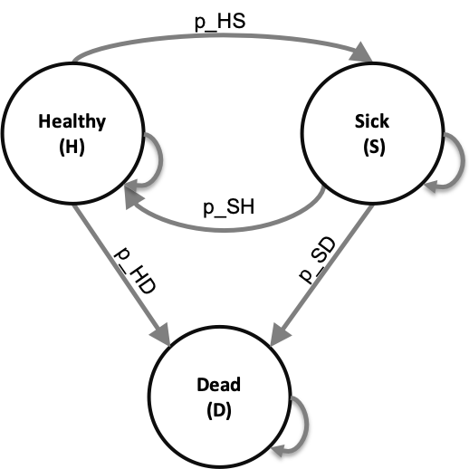

State-transition diagram of the 3-state model

| **Parameter** | **R name** | **Value** |
| --- | --- | --- |
| Time horizon ($n_t$) | `n_t` | 30 years |
| Names of health states ($n$) | `v_n` | H, S, D |
| Annual transition probabilities |  |  |
| - Disease onset (H to S) | `p_HS` | 0.30 |
| - Recovery (S to H) | `p_SH` | 0.15 |
| Annual mortality |  |  |
| - All-cause (H to D) | `p_HD` | 0.05 |
| - Disease specific (S to D) | `p_SD` | 0.20 |
| Annual costs |  |  |
| - Healthy individuals | `c_H` | $1,000 |
| - Sick individuals | `c_S` | $3,000 |
| - Dead individuals | `c_D` | $0 |
| Utility weights |  |  |
| - Healthy individuals | `u_H` | 1.00 |
| - Sick individuals | `u_S` | 0.60 |
| - Dead individuals | `u_D` | 0.00 |
| Transition rewards |  |  |
| - Utility decrement of healthy individuals | `du_HS` | 0.10 |
| when transitioning to S |  |  |
| - Cost of dying | `ic_D` | $4,000 |

### 01 Initial setup

We start by loading the packages and functions needed.

```r
#### 01.1 Load packages and functions ####
library(reshape2) # load reshape2 to transform data
library(ggplot2)  # load ggplot2 for nice looking plots
```

#### 01.2 External parameters

In this section, we specify the staring age of the cohort, the number of cycles, the names of the health states and model parameters.

```r
#### 01.2.1 General setup ####
age         <- 70  # age of starting cohort
n_t         <- 30  # time horizon, number of cycles
v_age_names <- age:(age + n_t - 1) # vector with age names
v_n <- c("H", "S", "D") # vector with the 3 health states of the model:
# Healthy (H), Sick (S), Dead (D)
n_states <- length(v_n) # number of health states
```

Next, we store the base-case parameters.

```r
#### 01.2.3 Generate initial set of base-case external parameters ####
# Costs
c_H   <- 1000   # cost of remaining one cycle healthy
c_S   <- 3000   # cost of remaining one cycle sick
c_D   <- 0      # cost of being dead (per cycle)
# State utilities
u_H   <- 1      # utility when healthy
u_S   <- 0.60   # utility when sick
u_D   <- 0      # utility when healthy
# Transition probabilities (per cycle)
p_HS  <- 0.30   # probability to become sick when healthy
p_HD  <- 0.05   # probability to die when healthy
p_SH  <- 0.15   # probability to become healthy when sick
p_SD  <- 0.20   # probability to die when sick
# Transition rewards
du_HS <- 0.10   # one-time utility decrement when becoming sick
ic_D  <- 4000   # one-time cost of dying
```

### 02 Define and initialize matrices and vectors

In this section, we initialize the matrices and vectors used for storing the data. The transition probability matrix, `m_P`, is initialized. The next step is to initialize the state vector `v_m0`. All individuals start healthy. This state vector is used to inform the first row of the cohort trace matrix `m_M`.

#### Equation 1-2

```r
#### 02.1 Initial state vector ####
# the cohort start in the Healthy health state
v_m0 <- c(H = 1, S = 0, D = 0)
v_m0
```

```
## H S D
## 1 0 0
```

```r
#### 02.2 Cohort trace
## Create the Markov cohort trace matrix m_M capturing the proportion of the cohort
# in each state at each cycle

m_M <- matrix(0,  # initialize cohort trace
              nrow = (n_t + 1), ncol = n_states,
              dimnames = list(0:n_t, v_n))

m_M[1, ] <- v_m0   # store the initial state vector
```

```r
#### 02.3 Transition probability matrix ####
# matrix m_P at the first cycle
m_P <- matrix(NA,
              nrow = n_states, ncol = n_states,
              dimnames = list(v_n, v_n))

# Fill in matrix
# From Healthy
m_P["H", "H"]  <- 1 - (p_HS + p_HD)
m_P["H", "S"]  <- p_HS
m_P["H", "D"]  <- p_HD
# From Sick
m_P["S", "H"]  <- p_SH
m_P["S", "S"]  <- 1 - (p_SH + p_SD)
m_P["S", "D"]  <- p_SD
# From Death
m_P["D", "H"]  <- 0
m_P["D", "S"]  <- 0
m_P["D", "D"]  <- 1

m_P # print the transition probability matrix
```

```
##      H    S    D
## H 0.65 0.30 0.05
## S 0.15 0.65 0.20
## D 0.00 0.00 1.00
```

We have determined all parameters for the general set up, we specified our input parameters, initialized all structures and filled the transition probability matrix `m_P` and the first row of our cohort trace `m_M`. The next step is running the Markov model.

### 03 Traditional cohort trace approach

In this section, we run the Markov model for the entire time horizon. The calculation shown in Equation 3 needs to be performed for all cycles. Therefore, we create a loop starting at `t = 1` until `t = n_t`. The transition probability matrix, `m_P` is multiplied with the cohort trace `m_M[t, ]`, using matrix multiplication, specified in `R` with `%*%`, to fill the next row of the `m_M[t + 1, ]`.

#### Equation 3

```r
for(t in 1:n_t){  # loop through the number of cycles
  # estimate the state vector for the next cycle (t + 1)
  m_M[t + 1, ] <- m_M[t, ] %*% m_P
}
```

#### Equation 4

When printing the first six rows of `m_M` we see that everyone starts healthy and over time the cohort transitions towards sick and dead.

```r
head(round(m_M, 3)) # show the first six lines of the cohort trace
```

```
##       H     S     D
## 0 1.000 0.000 0.000
## 1 0.650 0.300 0.050
## 2 0.468 0.390 0.143
## 3 0.362 0.394 0.244
## 4 0.295 0.365 0.341
## 5 0.246 0.325 0.428
```

Running the model using equation 3, results in the traditional cohort trace. This gives information about state occupation at each cycle and allows us to apply state rewards (e.g. `c_H`, `u_H`, etc.), but it is not possible to include the transition rewards (e.g. `du_HS` and `ic_D`). In order to include these rewards, we need to know when individuals made the transition. The dynamics-array approach facilitates this and will be explained in the next section.

### 04 Dynamics-array approach

#### Equation 5

```r
a_A <- array(0, dim = c(n_states, n_states, n_t + 1),
             dimnames = list(v_n, v_n, 0:n_t)) # initialize array
diag(a_A[, , 1]) <- v_m0 # store the initial state vector in the diagonal of A
a_A[, , 1] # print the first cycle
```

```
##   H S D
## H 1 0 0
## S 0 0 0
## D 0 0 0
```

#### Equation 6

Now we run the model using the dynamics-array approach. In this approach, iteratively over time, we multiply the transition probability matrix `m_P` with array `a_A` using element-wise multiplication, indicated with the `*` in `R`. The information about all transitions is stored in the `t + 1`-th “slice” of `a_A`.

```r
# run the model
for(t in 1:n_t){                     # loop through the number of cycles
  a_A[, , t + 1] <- colSums(a_A[, , t]) * m_P  # estimate the transition dynamics at t + 1
}
```

#### Equation 7 and 8

```r
a_A[, , 1:3] # shown for two cycles
```

```
## , , 0
##
##   H S D
## H 1 0 0
## S 0 0 0
## D 0 0 0
##
## , , 1
##
##      H   S    D
## H 0.65 0.3 0.05
## S 0.00 0.0 0.00
## D 0.00 0.0 0.00
##
## , , 2
##
##        H     S      D
## H 0.4225 0.195 0.0325
## S 0.0450 0.195 0.0600
## D 0.0000 0.000 0.0500
```

```r
sum(a_A[, , 3]) # sum for t = 3
```

```
## [1] 1
```

When you sum the values in each column of `a_A`, the health states towards which the individuals transition to, you get which proportion of the cohort was in each health state for that cycle. The code below shows this for the health state sick.

```r
sum(a_A[, "S", 3]) # sum the column of S at t = 3
```

```
## [1] 0.39
```

#### Equation 9

```r
# recovering M from A
m_MViaA <- t(colSums(a_A))   # sum over the columns of a_A and transpose
```

### 05 Apply state and transition rewards

By now you know how to run a state-transition cohort model using the dynamics-array approach and how to interpret or summarize the results. In this section, we demonstrate how to apply state and transition rewards. We start by initiating and filling two matrices for both costs and effects. On the diagonal are the costs for staying one cycle in that state (state rewards), while the costs off the diagonal are the costs for staying one cycle in that state plus the transition cost associated with that transition (transition rewards).

#### Equation 10

```r
#### 05.1 Create reward matrices for both costs and effects ####
m_R_costs <- m_R_effects <- matrix(NA,
                  nrow = n_states, ncol = n_states,
                  dimnames = list(v_n, v_n))

# Fill in matrix for costs
# To Healthy
m_R_costs["H", "H"]  <- c_H
m_R_costs["S", "H"]  <- c_H
m_R_costs["D", "H"]  <- c_H
# To Sick
m_R_costs["H", "S"]  <- c_S
m_R_costs["S", "S"]  <- c_S
m_R_costs["D", "S"]  <- c_S
# To Death
m_R_costs["H", "D"]  <- c_D + ic_D
m_R_costs["S", "D"]  <- c_D + ic_D
m_R_costs["D", "D"]  <- c_D

# Fill in matrix for effects
# To Healthy
m_R_effects["H", "H"]  <- u_H
m_R_effects["S", "H"]  <- u_H
m_R_effects["D", "H"]  <- u_H
# To Sick
m_R_effects["H", "S"]  <- u_S - du_HS
m_R_effects["S", "S"]  <- u_S
m_R_effects["D", "S"]  <- u_S
# to Death
m_R_effects["H", "D"]  <- u_D
m_R_effects["S", "D"]  <- u_D
m_R_effects["D", "D"]  <- u_D
```

```r
m_R_costs    # show the reward matrix for costs
```

```
##      H    S    D
## H 1000 3000 4000
## S 1000 3000 4000
## D 1000 3000    0
```

```r
m_R_effects  # show the reward matrix for effects
```

```
##   H   S D
## H 1 0.5 0
## S 1 0.6 0
## D 1 0.6 0
```

#### Equation 12

In this section we create outcome arrays, `a_Y`, one for costs, `a_Y_costs`, and one for effects,`a_Y_effects`. These arrays show the costs and QALYs generated with each transition at each cycle. By iteratively element-wise multiplication of the reward matrices, `m_R_costs` and `m_R_effects`, with array `a_A` we can fill the outcome arrays.

```r
#### 05.2 Expected QALYs and Costs per cycle for each strategy ####
a_Y_costs <- a_Y_effects <- array(0, dim = c(n_states, n_states, n_t + 1),
             dimnames = list(v_n, v_n, 0:n_t))

# initialize arrays
a_Y_costs[, , 1]   <- a_A[, , 1] * m_R_costs
a_Y_effects[, , 1] <- a_A[, , 1] * m_R_effects

for(t in 1:n_t){
# element-wise-multiplication of array A with the rewards matrices
a_Y_costs[, , t + 1]   <- a_A[, , t + 1] * m_R_costs
a_Y_effects[, , t + 1] <- a_A[, , t + 1] * m_R_effects
}
```

Please note that we are now showing all these calculations in a step-wise approach, resulting in having a couple of loops for time. All iterative process, creating `m_M`, `a_A` and the `m_R` and `a_Y`, can be combined within the same loop for time.

#### Equation 12

The final step is to calculate the total costs and QALYs. We first calculate the expected cost and QALYs per cycle and store them in the vectors `v_costs` and `v_QALYs`. Then, we sum the values within each vector to compute the total expected cost (`TC`) and QALYs (`TE`).

```r
# calculate the expected costs per cycle
v_costs <- rowSums(t(colSums(a_Y_costs)))
# calculate the expected QALYs per cycle
v_QALYs <- rowSums(t(colSums(a_Y_effects)))

TC <- sum(v_costs)  # calculate the total expected costs
TE <- sum(v_QALYs)  # calculate the total expected QALYS

v_results <- c(TC, TE)       # combine the total expected costs and QALYs
names(v_results) <- c("Costs", "Effect") # name the vector
v_results                    # print the results
```

```
##        Costs       Effect
## 19881.309167     6.637024
```

### 06 Plot cohort trace

The results of a cohort trace are much easier to interpret via a graph. Using the function `ggplot` we show the proportion of the cohort in each state (y-axis) at each cycle (x-axis) in Figure .

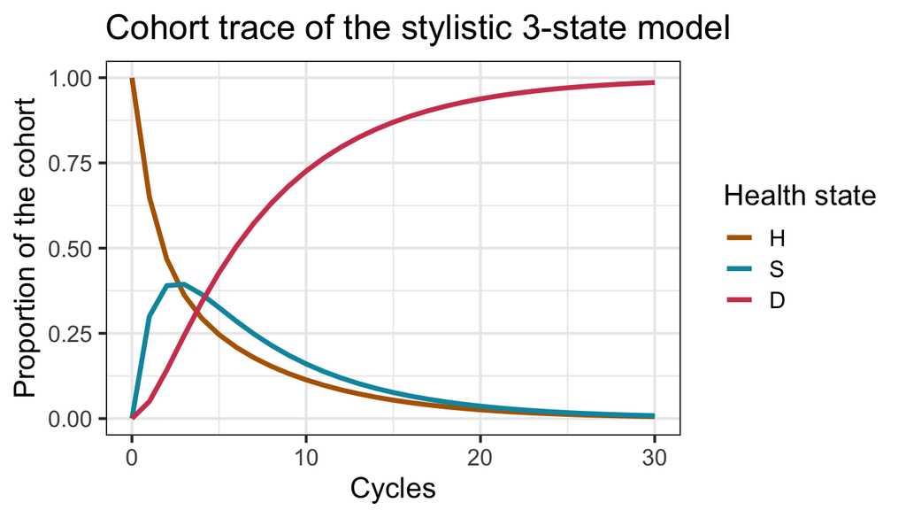

Cohort trace of the model

At the end of the model we save the important objects so they can be used without the need to run the model again.

```r
save(m_M, file = "../output/cohort_trace.RData") # save the object
save(a_A, file = "../output/array.RData") # save the object
```

### 07 Estimation of epidemiological measures

As mentioned in the brief report, full exposition of computing epidemiological measures from array A is case-specific and is beyond the scope of this brief report. We do however, like to illustrate the concept using a very simple example. For our illustrative 3-state model we can calculate the ratio of those than transitioned from sick to dead at each cycle to those that transitioned to dead from healthy and sick. To calculate this, we initiate a vector of lenght $n_t$ to store the data and since all individuals start out healthy the initial value of this vector is 0. Next, we iteratively calculate the ratio.

```r
v_e <- numeric(n_t + 1)   # create the vector v_e
v_e[1] <- 0               # initiate the vector
# calculate the ratio across all cycles starting in cycle 2
v_e[-1] <-  a_A["S", "D", -1] / (a_A["H", "D", -1] +  a_A["S", "D", -1])
```

Next, we prepare the data to get a nice plot.

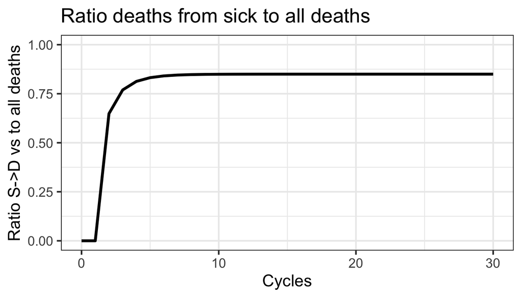

Ratio of those dying from sick to those dying from both healthy and sick

```r
df_e <- as.data.frame(cbind(0:n_t, v_e)) # create a dataframe with cycles and proportion that dies each cycle
colnames(df_e) <- c("cycle", "proportion") # name the columns of the dataframe
```

Our final step is to save the figure in the figs folder.

```r
ggsave("../figs/Proportion_death_from_sick.png", width = 8, height = 6) # save the plot
```

## Using the traditional cohort trace approach

With the traditional approach the Markov trace is calculated every cycle. This trace only shows how the cohort is distributed among the different health states over time, but no information about the transitions is available. In our stylistic 3-state model getting sick is associated with a sudden decrease of quality of life of 0.1 and in addition transitioning to dead incurs a one-time cost of $4,000. To incorporate these rewards, we need to make two extra temporary health states. One temporary state for those that transitioned to sick, Stemp, and one temporary state for those that die, Dtemp. The Stemp state makes is possible to incorporate the sudden decrease of quality of life and the Dtemp states is used to incorporate the extra cost. This means that with the traditional approach our model would have five health states: Healthy, Sick temporary, Sick, Dead temporary and Dead (see Figure ). The healthy individuals can transition to sick temporary state, dead temporary state or stay healthy. Temporary sick individuals, those that just turned sick, can fully recover, transitioning back to healthy, transition to the Dead temporary state or remain sick, which means that they transition to Sick. Sick individuals, can also fully recover, transitioning back to healthy, can transition to dead temporary or stay sick, which means they remain in the sick state. All individuals in the temporary dead state transition to the dead states. The dead state is the absorbing states.

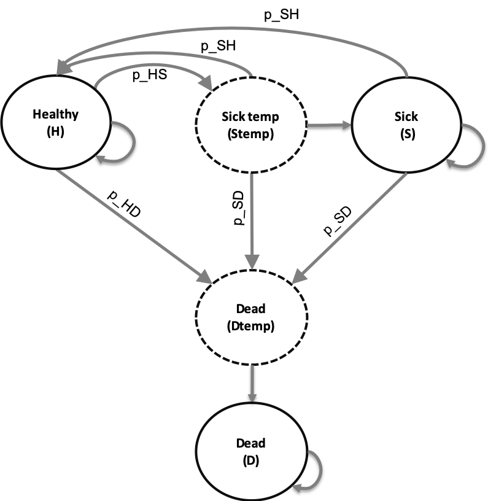

State-transition diagram of the 3-state model when using the cohort trace approach. The dashed lines around the temporary health states indicate that the individuals can only stay in that health state for one cycle.

In the next sections we describe how to run the model using the traditional cohort trace approach. All parameters are similar we and only provide code for parts that are different compared to the dynamics array approach

### Extra temporary health states

```r
v_n <- c("H", "Stemp", "S", "Dtemp", "D") # vector with the 3 health states of the model:
# Healthy (H), Sick (S), Dead (D) and two temporary health states one for Sick for the first time (Stemp) and one for dying (Dtemp)
n_states <- length(v_n) # number of health states
```

The transition probability matrix now has 5 and 5 columns.

```r
#### Transition probability matrix ####
# matrix m_P at the first cycle
m_P <- matrix(NA,
              nrow = n_states,
              ncol = n_states,
              dimnames = list(v_n, v_n))
```

The matrix is filled in a similar way compared to the array approach described above. Healthy individuals can only transition to the temporary sick state, Stemp, or dead state, Dtemp, or they stay healthy. Healthy inidividuals can not transition to sick, S, or dead, D.

```r
# Fill in matrix
# From Healthy
m_P["H", "H"]      <- 1 - (p_HS + p_HD)
m_P["H", "Stemp"]  <- p_HS
m_P["H", "S"]      <- 0
m_P["H", "Dtemp"]  <- p_HD
m_P["H", "D"]      <- 0

# From Sick temporary (first cycle being sick)
m_P["Stemp", "H"]     <- p_SH
m_P["Stemp", "Stemp"] <- 0
m_P["Stemp", "S"]     <- 1 - (p_SH + p_SD)
m_P["Stemp", "Dtemp"] <- p_SD
m_P["Stemp", "D"]     <- 0

# From Sick
m_P["S", "H"]         <- p_SH
m_P["S", "Stemp"]     <- 0
m_P["S", "S"]         <- 1 - (p_SH + p_SD)
m_P["S", "Dtemp"]     <- p_SD
m_P["S", "D"]         <- 0

# From Death temporary
m_P["Dtemp", "H"]     <- 0
m_P["Dtemp", "Stemp"] <- 0
m_P["Dtemp", "S"]     <- 0
m_P["Dtemp", "Dtemp"] <- 0
m_P["Dtemp", "D"]     <- 1

# From Death
m_P["D", "H"]         <- 0
m_P["D", "Stemp"]     <- 0
m_P["D", "S"]         <- 0
m_P["D", "Dtemp"]     <- 0
m_P["D", "D"]         <- 1

m_P # print the matrix
```

```
##          H Stemp    S Dtemp D
## H     0.65   0.3 0.00  0.05 0
## Stemp 0.15   0.0 0.65  0.20 0
## S     0.15   0.0 0.65  0.20 0
## Dtemp 0.00   0.0 0.00  0.00 1
## D     0.00   0.0 0.00  0.00 1
```

All individuals in the cohort start out healthy and this information is stored in the Markov cohort trace.

```r
#### Cohort trace matrix ####
## Initial state vector
v_m0 <- c(H = 1, Stemp = 0, S = 0, D = 0, Dtemp = 0) # the cohort starts healthy

## Create the Markov cohort trace matrix m_M that captures the proportion of the cohort in each state at each cycle
m_M <- matrix(0,
              nrow = (n_t + 1),
              ncol = n_states,
              dimnames = list(0:n_t, v_n)) # initialize cohort trace matrix
m_M[1, ] <- v_m0 # store the initial state vector in the first row of the cohort trace
```

Now we iteratively run the model

```r
#### Run the cSTM ####
for(t in 1:n_t){  # loop through the number of cycles
  # estimate the state vector for the next cycle (t + 1)
  m_M[t + 1, ] <- m_M[t, ] %*% m_P
}

head(m_M)
```

```
##           H      Stemp         S      Dtemp         D
## 0 1.0000000 0.00000000 0.0000000 0.00000000 0.0000000
## 1 0.6500000 0.30000000 0.0000000 0.05000000 0.0000000
## 2 0.4675000 0.19500000 0.1950000 0.09250000 0.0500000
## 3 0.3623750 0.14025000 0.2535000 0.10137500 0.1425000
## 4 0.2946062 0.10871250 0.2559375 0.09686875 0.2438750
## 5 0.2461916 0.08838187 0.2370225 0.08766031 0.3407438
```

While the array approach requires a matrix to apply the rewards, with the traditional cohort approach two vectors are enough. One vector for the utilities and one for the costs is created. The costs of dying, `ic_D` of values $4000 is applies to the proportion of the cohort in the temporary dead state. This are the individuals that just died and made those costs. The utility decrement `du_HS` is subtracted from the utility of being sick in the temporary health state. That is the proportion of the cohort that just transitioned from healthy to sick.

```r
#### State and transition rewards ####
## Create a vector to store rewards
v_R_costs   <- c(c_H, c_S, c_S, c_D + ic_D, c_D)
v_R_effects <- c(u_H, u_S - du_HS, u_S, u_D, u_D)
names(v_R_costs) <- names(v_R_effects) <- v_n
```

The expected QALYs and costs per cycle in turn can be calculated by matrix multiplication of `m_M` with the vector for costs `v_R_costs` and `v_R_effects`.

```r
#### Aggregate outcomes ####
v_costs <- m_M %*% v_R_costs          # calculate the expected costs per cycle
v_QALYs <- m_M %*% v_R_effects        # calculate the expected QALYs per cycle

TC <- sum(v_costs)                    # calculate the total expected costs
TE <- sum(v_QALYs)                    # calculate the total expected QALYS
v_results <- c(TC, TE)                # combine the total expected costs and QALYs
names(v_results) <- c("Costs", "Effect")  # name the vector
v_results                             # print the results
```

```
##        Costs       Effect
## 19881.309167     6.637024
```

## Approach comparison using a sensitivity analysis

We conducted a sensitivity analysis on computation efficiency of the two approaches, with computation efficiency defined as computation time in seconds and the computation storage in bytes of the two methods. The parameters of this sensitivity analysis were the number of states, $n_states$, and the number of cycles, $n_t$, in a cohort model. We varied the number of states from 2 to 62, incremented by 5, while the number of cycles varied from 12 to 1320, incremented by 12. The reasoning for these numbers is as follows. The simplest cohort model is a 2-state model, therefore the minimum number of health states is 2. The maximum number of health states is set to 60, since a cohort model with 60 health states is very uncommon and should not be performed, because other methods like microsimulations models are suited for those circumstances. For the number of cycles, we assume that the maximum time horizon for a model is 110 years (modelling an individual’s lifetime). When modelling this time horizon in monthly cycles, we get a total of 1320 cycles.

In order to capture and calculate transition and state rewards using the cohort trace approach, temporary states had to be created, since the transition reward for a state is only obtained when it is first visited. Without loss of generality, we assume there are no absorbing states and every state can be visited from any other state. Also, the transition probability matrices for both approaches were randomly sampled such that each entry is between 0 and 1 and each row adds up to 1. The rewards vectors and matrices for both approaches were also randomly sampled from appropriate distributions. We set the seed of `R`’s random number generator to assure reproducible results.

### Compare time:

2D line graph - by state, at 1320 cycles

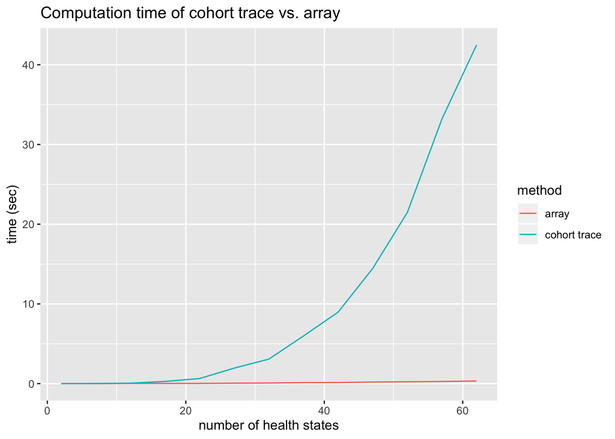

Computation time of cohort trace appraoch v.s array approach

### Zoom in on the y-axis

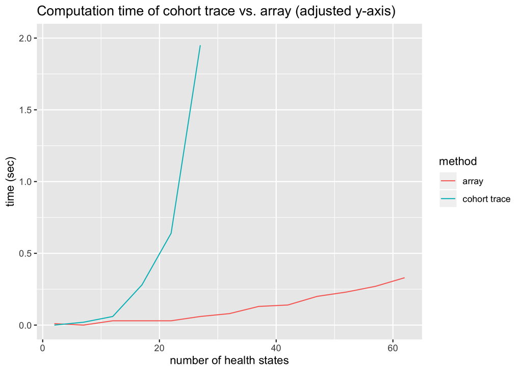

Computation time of cohort trace appraoch v.s array approach by health states when running 1320 cycles. This graphs is zoomed in on the y-axis to be able to see a change in the computation time of the array appraoch.

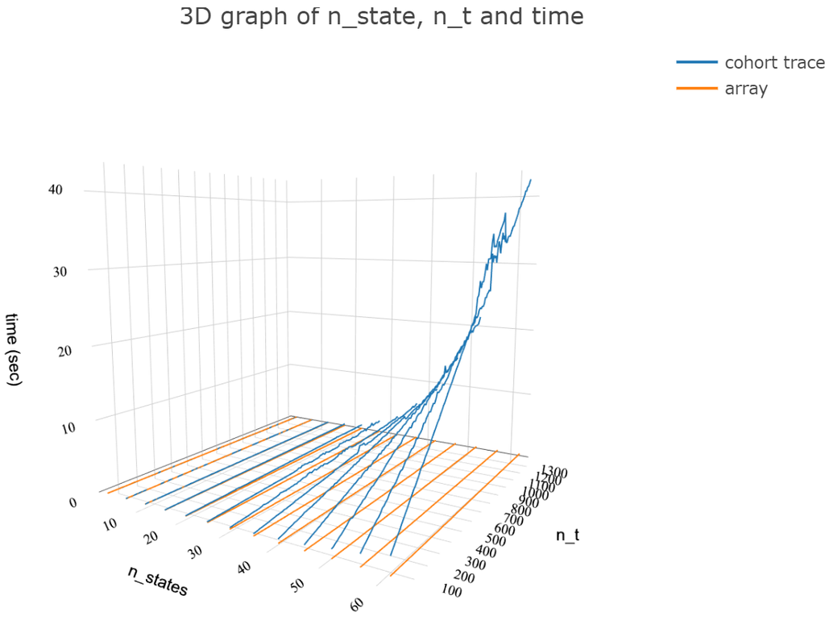

Computation time of cohort trace appraoch v.s array approach

At 1320 cycles, as the number of health states increases, the storage of both approaches increases (see Figure . When the number of health states is less than approximately 52, the cohort trace approach takes up less storage. But when the number of health states is above approximately 52, it takes up more storage.

[figure not shown]

Figure illustrates how computation storage of the two approaches vary as the number of health states and the number of cycles increase simultaneously. We see that the storage increases as when either the number of health states or the number of cycles increases. Both approaches take up approximately the same amount of storage before around 50 health states. After 50 health states the cohort trace approach takes up more memory compared to the array approach.

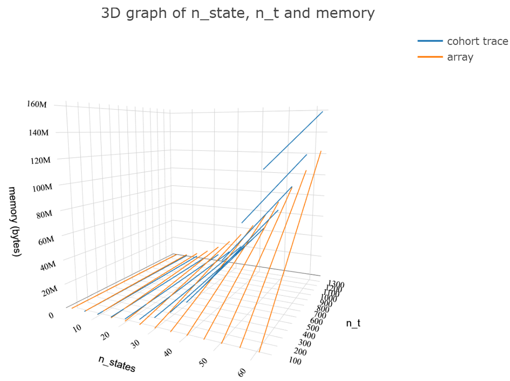

Computation memory of cohort trace appraoch v.s array approach

## References

Alarid-Escudero, Fernando et al. 2019. “A Need for Change! A Coding Framework for Improving Transparency in Decision Modeling.” PharmacoEconomics. https://doi.org/10.1007/s40273-019-00837-x.